# Founders Reversal Learning Data: Heritability and Plotting

Michael C. Saul (michael.saul [at] jax.org)

# 1 Background

## 1.1 Motivation

### 1.1.1 Purpose of analysis

This analysis is performed to process the reversal learning data and calculate:

1. Heritability
2. Strain-by-sex means and standard errors for plotting

The preprocessing script `reversal_import_preprocess.Rmd` was used to filter the data to only those data requiring reporting.

# 2 Analysis

## 2.1 Setup

### 2.1.1 Working directory

All chunks will run in the working folder for this experiment.

```r
script_root_dir = "~/Downloads/founders_heritability/"
knitr::opts_knit$set(root.dir = script_root_dir)
```

Getting current date

```r
current_date = format(Sys.time(),"%Y-%m-%d")
```

### 2.1.2 R libraries

Calling R libraries necessary for this analysis.

```r
library("tidyverse")
```

```r
library("lubridate")
library("cowplot")
library("MASS")
library("ggbeeswarm")
```

### 2.1.3 Getting `norm_rank_transform` function

```r
norm_rank_transform = function(x, c = (0)) {
  stopifnot(is.numeric(x) & is.vector(x))
  N = length(x)
  return(qnorm((rank(x) - c) / (N - (2 * c) + 1)))
}
```

## 2.2 Importing data

## 2.3 Importing and displaying raw reversal learning data

Getting data from the filtering script.

```r
reversal_data = readRDS(paste(script_root_dir, "data/reversal_data_preprocessed_2019-10-28.RDS", sep = ""))
```

Displaying raw data.

```r
reversal_data = reversal_data[which(!(is.na(reversal_data$Avg_Anticip_C_R))),]
reversal_data
```

|  | ID | Site | Cohort | Strain | Sex | Avg_Anticip_C_R |
| --- | --- | --- | --- | --- | --- | --- |
| 1NODF1 | 1NODF1 | Binghamton | 1 | NOD/ShiLtJ | F | 1.03000000 |
| 1NODF3 | 1NODF3 | Binghamton | 1 | NOD/ShiLtJ | F | 2.65000000 |
| 1NODM2 | 1NODM2 | Binghamton | 1 | NOD/ShiLtJ | M | 0.65800000 |
| 2NODF5 | 2NODF5 | Binghamton | 2 | NOD/ShiLtJ | F | 0.76500000 |
| 2NODM6 | 2NODM6 | Binghamton | 2 | NOD/ShiLtJ | M | 2.30000000 |
| 3NODF7 | 3NODF7 | Binghamton | 3 | NOD/ShiLtJ | F | 1.27450000 |
| 3NODM7 | 3NODM7 | Binghamton | 3 | NOD/ShiLtJ | M | 1.93100000 |
| 4NODF11 | 4NODF11 | Binghamton | 4 | NOD/ShiLtJ | F | 0.37209302 |
| 4NODM10 | 4NODM10 | Binghamton | 4 | NOD/ShiLtJ | M | 0.63428571 |
| 4NODM12 | 4NODM12 | Binghamton | 4 | NOD/ShiLtJ | M | 0.49090909 |

[output cut: 187 more lines]

Getting founders strain key

```r
founders_key = readRDS("~/Desktop/cc_do_founders_key.RDS")
row.names(founders_key) = founders_key$strain
```

### 2.3.1 Fitting ANOVA model for reversal data

Looking at the residuals of the simplest model first.

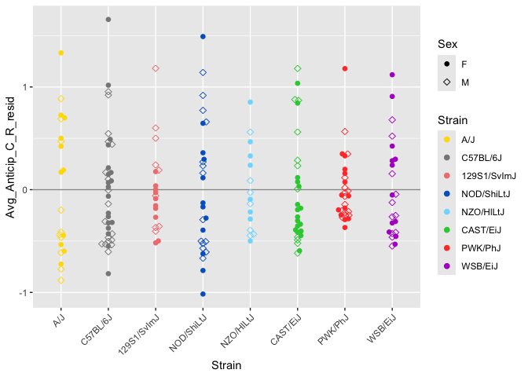

```r
reversal_resid = reversal_data
reversal_resid$Avg_Anticip_C_R_resid = resid(lm(Avg_Anticip_C_R ~ Site + Strain, data = reversal_resid))
reversal_resid$Strain = factor(reversal_resid$Strain,
                               levels = founders_key$strain,
                               ordered = TRUE)

ggplot(data = reversal_resid, aes(x = Strain, y = Avg_Anticip_C_R_resid, color = Strain, shape = Sex)) +
  geom_hline(yintercept = 0, col = "#999999") +
  geom_beeswarm(size = 2) +
  scale_color_manual(values = founders_key$collaborative_cross_color_broman) +
  theme(axis.text.x = element_text(angle = 45, hjust = 1)) +
  scale_shape_manual(values = c(16,23))
```

These residuals look very good, but there is some skewness to the residuals. It may be of benefit to look at a Box-Cox power transform to see if a transformation is merited.

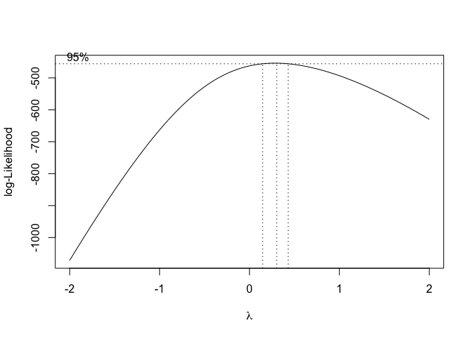

```r
boxcox(lm(Avg_Anticip_C_R ~ Site + Strain, data = reversal_resid))
```

The Box-Cox log-likelihood centers around 1/3, which indicates that a cube root transformation may be advantageous.

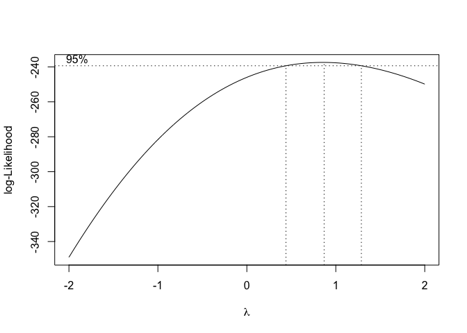

```r
cubert = function(x) {
  return(sign(x) * (abs(x) ^ (1/3)))
}

reversal_resid$Avg_Anticip_C_R_cubert = cubert(reversal_resid$Avg_Anticip_C_R)
boxcox(lm(Avg_Anticip_C_R_cubert ~ Site + Strain, data = reversal_resid))
```

This centers closer to 1. Looking at the residuals.

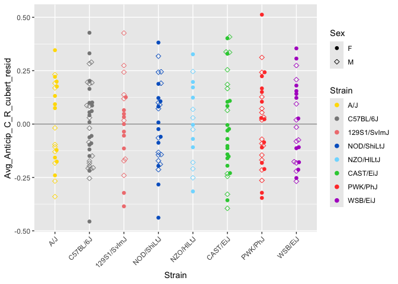

```r
reversal_resid$Avg_Anticip_C_R_cubert_resid = resid(lm(Avg_Anticip_C_R_cubert ~ Site + Strain, data = reversal_resid))

ggplot(data = reversal_resid, aes(x = Strain, y = Avg_Anticip_C_R_cubert_resid, color = Strain, shape = Sex)) +
  geom_hline(yintercept = 0, col = "#999999") +
  geom_beeswarm(size = 2) +
  scale_color_manual(values = founders_key$collaborative_cross_color_broman) +
  theme(axis.text.x = element_text(angle = 45, hjust = 1)) +
  scale_shape_manual(values = c(16,23))
```

These residuals are very good without any skewness. Cube root transforming data and proceeding with model selection.

```r
reversal_data$Avg_Anticip_C_R_cubert = cubert(reversal_data$Avg_Anticip_C_R)

AICs = c()
AICs["AIC_inter_site"] = AIC(lm(Avg_Anticip_C_R_cubert ~ Site + Strain + Sex + Strain:Sex, data = reversal_data))
AICs["AIC_inter"] = AIC(lm(Avg_Anticip_C_R_cubert ~ Strain + Sex + Strain:Sex, data = reversal_data))
AICs["AIC_interonly_site"] = AIC(lm(Avg_Anticip_C_R_cubert ~ Site + Strain + Strain:Sex, data = reversal_data))
AICs["AIC_interonly"] = AIC(lm(Avg_Anticip_C_R_cubert ~ Strain + Strain:Sex, data = reversal_data))
AICs["AIC_nointer_site"] = AIC(lm(Avg_Anticip_C_R_cubert ~ Site + Strain + Sex, data = reversal_data))
AICs["AIC_nointer"] = AIC(lm(Avg_Anticip_C_R_cubert ~ Strain + Sex, data = reversal_data))
AICs["AIC_nosex_site"] = AIC(lm(Avg_Anticip_C_R_cubert ~ Site + Strain, data = reversal_data))
AICs["AIC_nosex"] = AIC(lm(Avg_Anticip_C_R_cubert ~ Strain, data = reversal_data))
AICs["AIC_sexonly_site"] =  AIC(lm(Avg_Anticip_C_R_cubert ~ Site + Sex, data = reversal_data))
AICs["AIC_sexonly"] =  AIC(lm(Avg_Anticip_C_R_cubert ~ Sex, data = reversal_data))

AICs
```

```
##     AIC_inter_site          AIC_inter AIC_interonly_site      AIC_interonly
##         -47.775278         -47.637680         -47.775278         -47.637680
##   AIC_nointer_site        AIC_nointer     AIC_nosex_site          AIC_nosex
##         -54.893837         -54.434379         -56.799570         -56.359819
##   AIC_sexonly_site        AIC_sexonly
##          -7.437266          -7.346786
```

```r
BICs = c()
BICs["BIC_inter_site"] = BIC(lm(Avg_Anticip_C_R_cubert ~ Site + Strain + Sex + Strain:Sex, data = reversal_data))
BICs["BIC_inter"] = BIC(lm(Avg_Anticip_C_R_cubert ~ Strain + Sex + Strain:Sex, data = reversal_data))
BICs["BIC_interonly_site"] = BIC(lm(Avg_Anticip_C_R_cubert ~ Site + Strain + Strain:Sex, data = reversal_data))
BICs["BIC_interonly"] = BIC(lm(Avg_Anticip_C_R_cubert ~ Strain + Strain:Sex, data = reversal_data))
BICs["BIC_nointer_site"] = BIC(lm(Avg_Anticip_C_R_cubert ~ Site + Strain + Sex, data = reversal_data))
BICs["BIC_nointer"] = BIC(lm(Avg_Anticip_C_R_cubert ~ Strain + Sex, data = reversal_data))
BICs["BIC_nosex_site"] = BIC(lm(Avg_Anticip_C_R_cubert ~ Site + Strain, data = reversal_data))
BICs["BIC_nosex"] = BIC(lm(Avg_Anticip_C_R_cubert ~ Strain, data = reversal_data))
BICs["BIC_sexonly_site"] =  BIC(lm(Avg_Anticip_C_R_cubert ~ Site + Sex, data = reversal_data))
BICs["BIC_sexonly"] =  BIC(lm(Avg_Anticip_C_R_cubert ~ Sex, data = reversal_data))

BICs
```

```
##     BIC_inter_site          BIC_inter BIC_interonly_site      BIC_interonly
##          11.322390           8.176783          11.322390           8.176783
##   BIC_nointer_site        BIC_nointer     BIC_nosex_site          BIC_nosex
##         -18.778596         -21.602342         -23.967533         -26.810985
##   BIC_sexonly_site        BIC_sexonly
##           5.695549           2.502825
```

The best model for heritability differs depending upon AIC vs BIC. BIC punishes added variables more strongly and indicates that the strongest model for heritability is the one containing only strain without the site additive covariate. However, site is probably an important factor.

Showing ANOVA table for the full model.

```r
anova(lm(Avg_Anticip_C_R_cubert ~ Site + Strain + Sex + Strain:Sex, data = reversal_data))
```

|  | Df | Sum Sq | Mean Sq | F value | Pr(>F) |
| --- | --- | --- | --- | --- | --- |
| Site | 1 | 0.113547755 | 0.113547755 | 2.71109774 | 1.013972e-01 |
| Strain | 7 | 2.854756960 | 0.407822423 | 9.73728145 | 2.898191e-10 |
| Sex | 1 | 0.003736585 | 0.003736585 | 0.08921575 | 7.655211e-01 |
| Strain:Sex | 7 | 0.267994745 | 0.038284964 | 0.91410243 | 4.967830e-01 |
| Residuals | 180 | 7.538863538 | 0.041882575 | NA | NA |

No evidence of sex effect or strain:sex interaction. Showing ANOVA table for the reduced model with site.

```r
anova(lm(Avg_Anticip_C_R_cubert ~ Site + Strain, data = reversal_data))
```

|  | Df | Sum Sq | Mean Sq | F value | Pr(>F) |
| --- | --- | --- | --- | --- | --- |
| Site | 1 | 0.1135478 | 0.11354776 | 2.733080 | 9.995849e-02 |
| Strain | 7 | 2.8547570 | 0.40782242 | 9.816233 | 2.062177e-10 |
| Residuals | 188 | 7.8105949 | 0.04154572 | NA | NA |

Showing ANOVA table for the reduced model without site.

```r
anova(lm(Avg_Anticip_C_R_cubert ~ Strain, data = reversal_data))
```

|  | Df | Sum Sq | Mean Sq | F value | Pr(>F) |
| --- | --- | --- | --- | --- | --- |
| Strain | 7 | 2.870973 | 0.41013896 | 9.80235 | 2.092555e-10 |
| Residuals | 189 | 7.907927 | 0.04184088 | NA | NA |

The reduced model with site included be used for downstream heritability calculations.

### 2.3.2 Calculating heritability for reversal data

Calculating heritability using the ANOVA table from the best fitting model. Using the following equation:

$h^2=\displaystyle{{MS_{strain}-MS_{resid}}\over{MS_{strain} + (n_{mean} - 1) * MS_{resid}}}$

where $MS_{strain}$ is the mean square of the strain differences, $MS_{resid}$ is the mean square of the residuals, and $n_{mean}$ is the mean sample size of a strain. Ignoring the additive covariate of site, which is a blocking variable.

```r
h2_strainanova <- function(msgenetics, mserror, n) {
  return((msgenetics - mserror) / (msgenetics + (n - 1) * mserror))
}

mean_n = nrow(reversal_data) / length(unique(reversal_data[,"Strain"]))
anova_reversal = anova(lm(Avg_Anticip_C_R_cubert ~ Site + Strain, data = reversal_data))
anova_reversal_df = as.data.frame(anova_reversal)
h2_reversal = h2_strainanova(anova_reversal_df["Strain","Mean Sq"],
                             anova_reversal_df["Residuals","Mean Sq"],
                             mean_n)
h2_reversal
```

```
## [1] 0.2636336
```

The heritability of 0.26 is good.

### 2.3.3 Plotting strain x sex means

Plotting the strain:sex information for these data.

```r
reversal_summary = reversal_data %>%
  group_by(Strain, Sex) %>%
  summarize(Strain_Sex_mean = mean(Avg_Anticip_C_R_cubert, na.rm = TRUE),
            Strain_Sex_sem = sd(Avg_Anticip_C_R_cubert, na.rm = TRUE) / length(which(!is.na(Avg_Anticip_C_R_cubert)))) %>%
  mutate(Strain_Sex = paste(Strain, gsub("^([MF]).*$", "\\1", Sex), sep = " "),
         Strain_Sex_mean_backtrans = Strain_Sex_mean ^ 3,
         Strain_Sex_ul = (Strain_Sex_mean + Strain_Sex_sem) ^ 3,
         Strain_Sex_ll = (Strain_Sex_mean - Strain_Sex_sem) ^ 3)
```

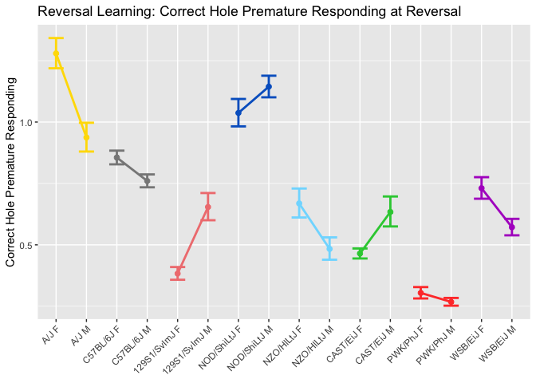

```r
reversal_summary = as.data.frame(reversal_summary)
reversal_summary$Strain_Sex = factor(reversal_summary$Strain_Sex,
                                  levels = paste(rep(founders_key$strain, each = 2), rep(c(" F", " M"), times = 8), sep = ""),
                                  ordered = TRUE)
reversal_summary$Strain = factor(reversal_summary$Strain,
                              levels = founders_key$strain,
                              ordered = TRUE)

reversal_strain_sex_plot = ggplot(data = reversal_summary, aes(x = Strain_Sex, y = Strain_Sex_mean_backtrans, color = Strain, group = Strain)) +
  geom_line(size = 1) +
  geom_point(size = 2) +
  geom_errorbar(aes(ymin = Strain_Sex_ll, ymax = Strain_Sex_ul), width = 0.5, size = 1) +
  scale_color_manual(values = founders_key$collaborative_cross_color_broman) +
  theme(axis.text.x = element_text(angle = 45, hjust = 1), legend.position="none") +
  xlab(NULL) +
  ylab("Correct Hole Premature Responding") +
  ggtitle("Reversal Learning: Correct Hole Premature Responding at Reversal")
reversal_strain_sex_plot
```

Plotting raw reversal data

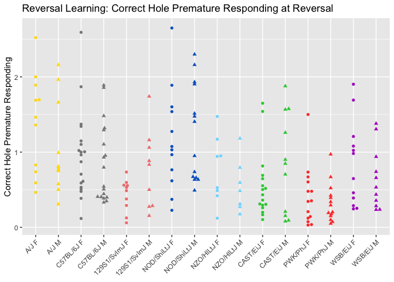

```r
reversal_data$Strain_Sex = factor(paste(reversal_data$Strain, gsub("^([MF]).*$", "\\1", reversal_data$Sex), sep = " "),
                               levels = levels(reversal_summary$Strain_Sex),
                               ordered = TRUE)
reversal_data$Strain = factor(reversal_data$Strain,
                           levels = founders_key$strain,
                           ordered = TRUE)
raw_data_plot = ggplot(data = reversal_data, aes(x = Strain_Sex, y = Avg_Anticip_C_R, color = Strain, shape = Sex)) +
  geom_beeswarm() +
  scale_color_manual(values = founders_key$collaborative_cross_color_broman) +
  theme(axis.text.x = element_text(angle = 45, hjust = 1), legend.position="none") +
  xlab(NULL) +
  ylab("Correct Hole Premature Responding") +
  ggtitle("Reversal Learning: Correct Hole Premature Responding at Reversal")
raw_data_plot
```

Saving plot

```r
saveRDS(raw_data_plot, "./output/founders_reversal_raw_data_plot.RDS")
saveRDS(reversal_strain_sex_plot, "./output/founders_reversal_strain_sex_plot.RDS")
```

# 3 Reproducibility Information

## 3.1 Software Used

### 3.1.1 R session and OS information

```r
reversal_plot_sessionInfo
```

[output not shown]

```r
saveRDS(reversal_plot_sessionInfo, paste(script_root_dir, "./output/reversal_plot_sessionInfo_",current_date,".RDS", sep = ""), compress="xz")
```

## 3.2 Document Control

This document was prepared using RMarkdown in RStudio.